# Data Visualization using Cancer Patient Data

Merve Ozdemir

2025-07-23

## Introduction

In this project, I practiced my data analysis and visualization skills with R, using a public dataset of cancer patients in Denmark. I examined demographic trends, cancer types, and age distributions to understand patterns in diagnosis and treatment.

I downloaded the “Cancer Patient Data in Denmark” dataset through Kaggle, a data science platform that contains publicly available datasets. The dataset contains 3,000 rows and 25 variables including cancer type, age, treatment details, risk factors, and survival outcomes.

Below, I share my code, plots and thought process throughout the project, as I explore the dataset and try to come up with interesting questions and hypotheses.

## Getting started: Loading libraries and data

```r
# Load required packages
library(tidyverse)
# Read the dataset (assumes file is in the same directory)
data <- read_csv("cancer_data_denmark.csv")
# View first few rows
head(data)
```

```
## # A tibble: 6 × 25
##   Patient_ID   Age Gender Region Cancer_Type Stage Diagnosis_Date Treatment_Type
##        <dbl> <dbl> <chr>  <chr>  <chr>       <chr> <date>         <chr>
## 1          1    69 Male   Hoved… Leukemia    III   2015-06-26     Radiation
## 2          2    41 Male   Sjæll… Lung        I     2016-03-05     Hormone Thera…
## 3          3    47 Female Sydda… Prostate    II    2017-09-17     Radiation
## 4          4    66 Male   Midtj… Skin        I     2018-03-07     Immunotherapy
## 5          5    72 Male   Sydda… Breast      II    2019-11-09     Chemotherapy
## 6          6    35 Female Hoved… Skin        II    2018-09-29     Hormone Thera…
## # ℹ 17 more variables: Treatment_Start_Date <date>, Treatment_End_Date <date>,
## #   Tumor_Size_cm <dbl>, Lymph_Nodes_Examined <dbl>,
## #   Lymph_Nodes_Positive <dbl>, Metastasis <chr>, Genetic_Mutation <chr>,
## #   Smoking_Status <chr>, Alcohol_Consumption <chr>, BMI <dbl>,
## #   Comorbidities <chr>, Family_History <chr>, Survival_Months <dbl>,
## #   Relapse <chr>, Occupation <chr>, Income_Level <chr>, Followup_Date <date>
```

## Exploring the data with basic plots

The first thing I was interested in is the cancer types included in the dataset. I thus started with a bar plot showing the frequency of different cancer types. When I first generated this plot I noticed that the difference in the count of different cancer types was very small compared to the total observations, so I used coord_cartesian() to “zoom in” on the y axis to better visualize the difference.

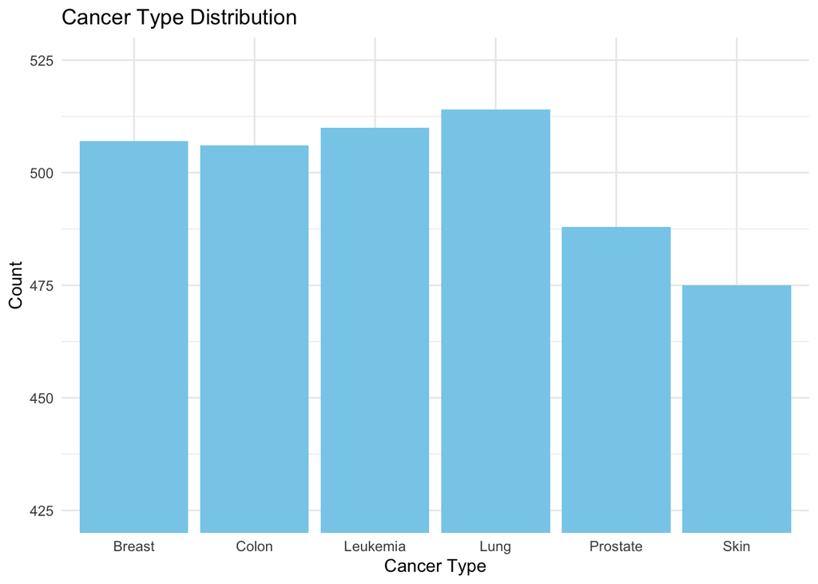

```r
# Bar plot
plot_cancer_type <- ggplot(data, aes(x = Cancer_Type)) +
  geom_bar(fill = "skyblue") +
  coord_cartesian(ylim = c(425, 525)) +
  labs(
    title = "Cancer Type Distribution",
    x = "Cancer Type",
    y = "Count"
  ) +
  theme_minimal()

ggsave("plots/cancer_type_distribution.png", plot = plot_cancer_type, width = 8, height = 6, dpi = 300, bg = "white")

plot_cancer_type
```

Next, I visualized the distribution of patient ages using a density plot. I added transparency (alpha) to make the background and gridlines more visible.

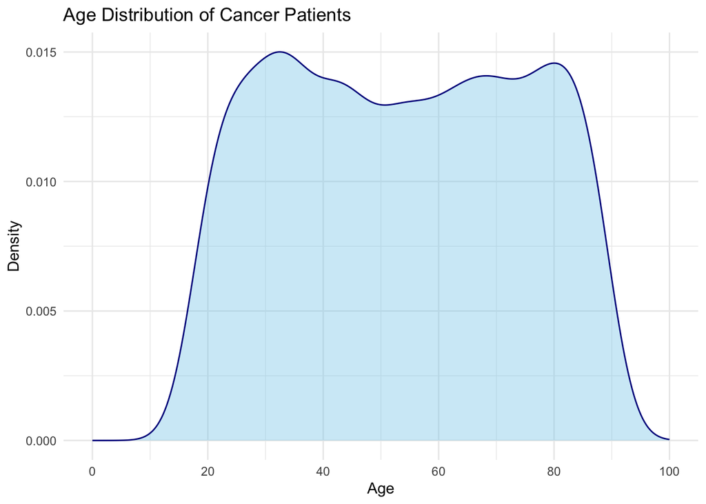

```r
plot_age <- ggplot(data, aes(x = Age)) +
  geom_density(fill = "skyblue", color = "darkblue", alpha = 0.4) +
  scale_x_continuous(limits = c(0, 100), breaks = seq(0, 100, 20)) +
  labs(
    title = "Age Distribution of Cancer Patients",
    x = "Age",
    y = "Density"
  ) +
  theme_minimal()

ggsave("plots/age_distribution.png", plot = plot_age, width = 8, height = 6, dpi = 300, bg = "white")

plot_age
```

The distributions were similar to what I expected. Now that I have this most basic info about the patients in the dataset (i.e. cancer type and age), I want to combine this information to see whether there are any interesting trends I could observe. For instance, is there any cancer type where the patients diagnosed are overall “younger” than in others?

I generated a violin plot to see the age distribution across cancer types in my dataset.

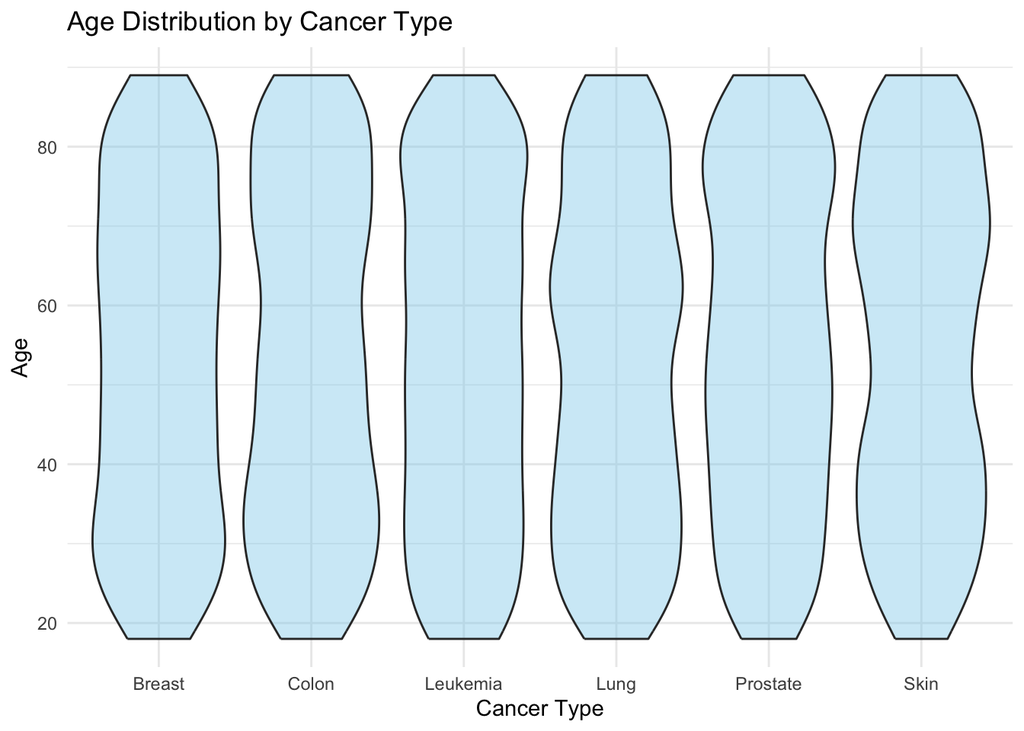

```r
plot_age_vs_cancertype <- ggplot(data, aes(x = Cancer_Type, y = Age)) + geom_violin(fill = "skyblue", alpha = 0.4) + labs(title = "Age Distribution by Cancer Type",
       x = "Cancer Type",
       y = "Age") +
  theme_minimal()

ggsave("plots/age_vs_cancertype.png", plot = plot_age_vs_cancertype, width = 8, height = 6, dpi = 300, bg = "white")

plot_age_vs_cancertype
```

I wondered if age also factors into survival of patients.

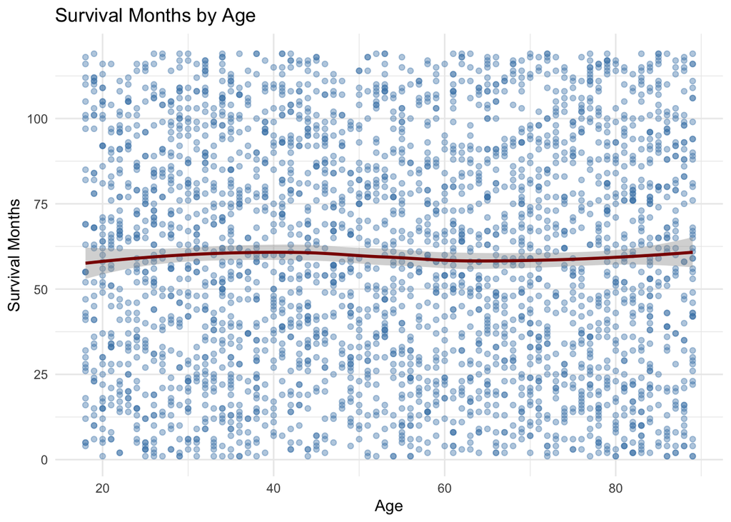

```r
plot_age_vs_survival <- ggplot(data, aes(x = Age, y = Survival_Months)) +
  geom_point(alpha = 0.4, color = "steelblue") +
  geom_smooth(method = "loess", se = TRUE, color = "darkred") +  # trend line
  labs(title = "Survival Months by Age",
       x = "Age",
       y = "Survival Months") +
  theme_minimal()

ggsave("plots/age_vs_survival.png", plot = plot_age_vs_survival, width = 8, height = 6, dpi = 300, bg = "white")
plot_age_vs_survival
```

Interesting! I would have expected age to affect survival outcome, but that doesn’t seem to be the case, at least not at first glance. Overall, there doesn’t seem to be a starking difference in the age distribution across cancers. What about gender?

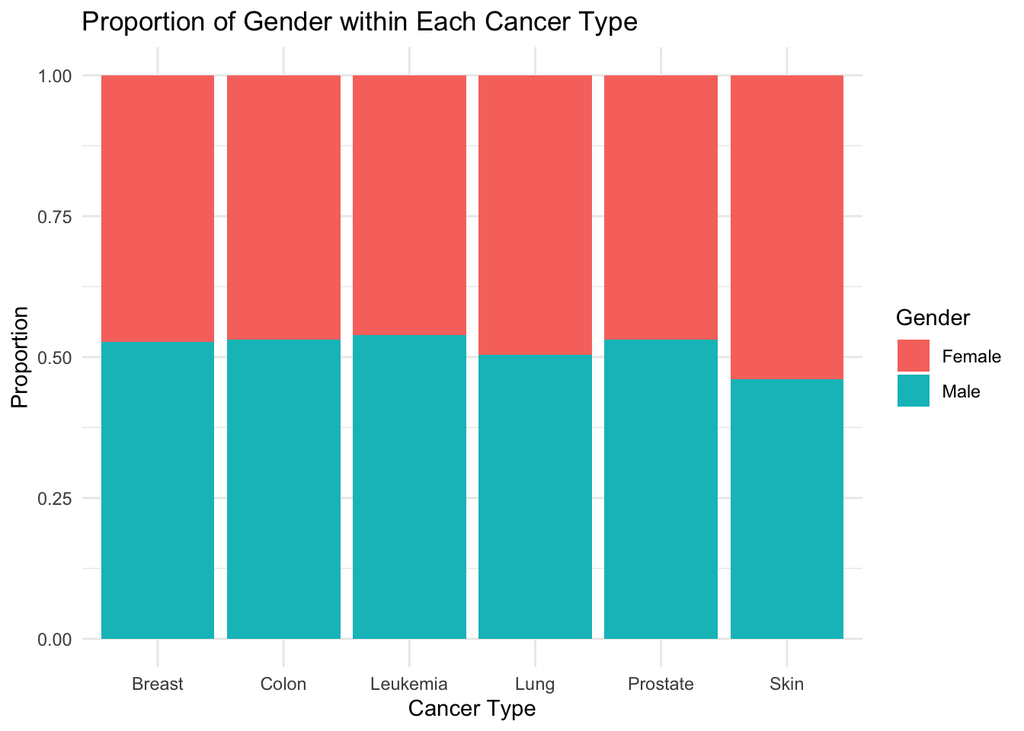

```r
plot_gender_vs_cancertype <- ggplot(data, aes(x = Cancer_Type, fill = Gender)) +
  geom_bar(position = "fill") +
  labs(title = "Proportion of Gender within Each Cancer Type",
       x = "Cancer Type",
       y = "Proportion",
       fill = "Gender") +
  theme_minimal()

ggsave("plots/gender_vs_cancertype.png", plot = plot_gender_vs_cancertype, width = 8, height = 6, dpi = 300, bg = "white")

plot_gender_vs_cancertype
```

Seems like gender differences, too, are quite subtle in all types of cancer included in the dataset. Next, I wanted to see whether there were differences in survival outcome across different cancers, whether some cancers were more “deadly” than others. Of course, survival depends on many factors but it is still interesting to look for overall trends.

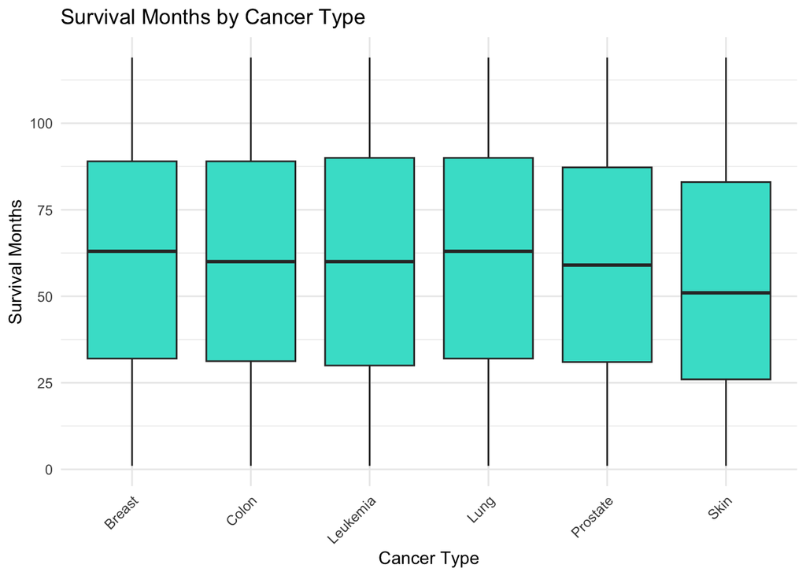

```r
plot_survival_vs_cancertype <- ggplot(data, aes(x = Cancer_Type, y = Survival_Months)) +
  geom_boxplot(fill = "turquoise") +
  labs(title = "Survival Months by Cancer Type",
       x = "Cancer Type",
       y = "Survival Months") +
  theme_minimal() +
  theme(axis.text.x = element_text(angle = 45, hjust = 1))

ggsave("plots/survival_vs_cancertype.png", plot = plot_survival_vs_cancertype, width = 8, height = 6, dpi = 300, bg = "white")

plot_survival_vs_cancertype
```

Similarly, do certain cancers have more occurances of relapse?

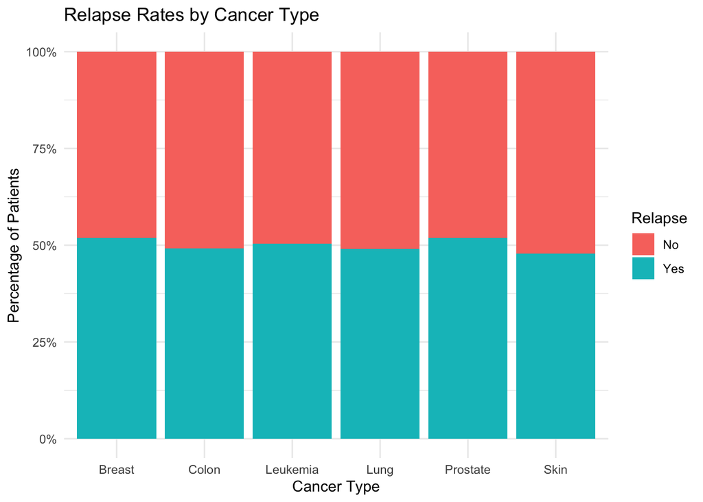

```r
plot_relapse_vs_cancertype <- ggplot(data, aes(x = Cancer_Type, fill = Relapse)) + scale_y_continuous(labels = scales::percent_format()) + geom_bar(position = "fill") + labs(
    title = "Relapse Rates by Cancer Type",
    x = "Cancer Type",
    y = "Percentage of Patients",
    fill = "Relapse"
  ) +
  theme_minimal()

ggsave("plots/relapse_vs_cancertype.png", plot = plot_relapse_vs_cancertype, width = 8, height = 6, dpi = 300, bg = "white")

plot_relapse_vs_cancertype
```

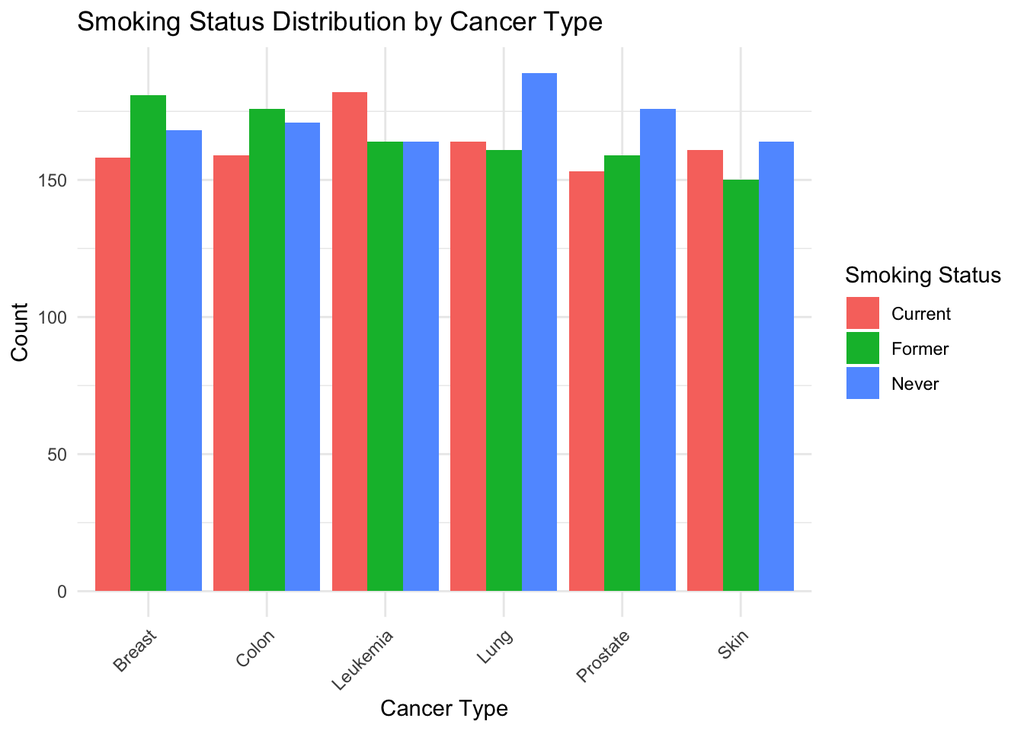

```r
plot_smoking <- ggplot(data, aes(x = Cancer_Type, fill = Smoking_Status)) +
  geom_bar(position = "dodge") +  # proportions within cancer type
  labs(title = "Smoking Status Distribution by Cancer Type",
       x = "Cancer Type",
       y = "Count",
       fill = "Smoking Status") +
  theme_minimal() +
  theme(axis.text.x = element_text(angle = 45, hjust = 1))

ggsave("plots/smoking.png", plot = plot_smoking, width = 8, height = 6, dpi = 300, bg = "white")

plot_smoking
```

At the first glance, what was most interesting to me with this plot is that there are more non-smokers who were diagnosed with lung cancer than former/current smokers. But of course, smokers in this dataset are separated into “former” and “current” smokers. Unfortunately, I don’t have enough information about the “study” conducted (since it isn’t real–this dataset was created for educational purposes) I don’t know what “former” implies; these patients could have quit smoking years ago, or maybe only for a week. So I’m not so interested in this labeling, I am rather interested in comparing people who never smoked with people who are (or were, at one point) smokers.

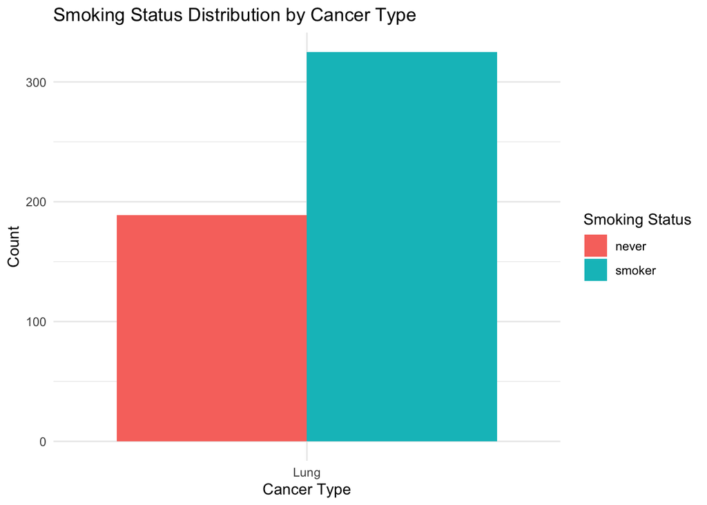

```r
lung_cancer_data <- data %>% filter(Cancer_Type == "Lung") %>% mutate(Smoking_Status = ifelse(Smoking_Status == "Never", "never", "smoker")) #reminder of syntax: ifelse(condition, value_if_true, value_if_false)

plot_lung_cancer_data <- lung_cancer_data %>% ggplot(aes(x = Cancer_Type, fill = Smoking_Status)) + geom_bar(position = "dodge") + labs(title = "Smoking Status Distribution by Cancer Type",
       x = "Cancer Type",
       y = "Count",
       fill = "Smoking Status") +
  theme_minimal()

ggsave("plots/lung_cancer.png", plot = plot_lung_cancer_data, width = 8, height = 6, dpi = 300, bg = "white")

plot_lung_cancer_data
```

Now this makes a lot more sense to me visually! And what if we used these same simplified smoker vs. non-smoker categories to recreate the plot from before, across all cancer types?

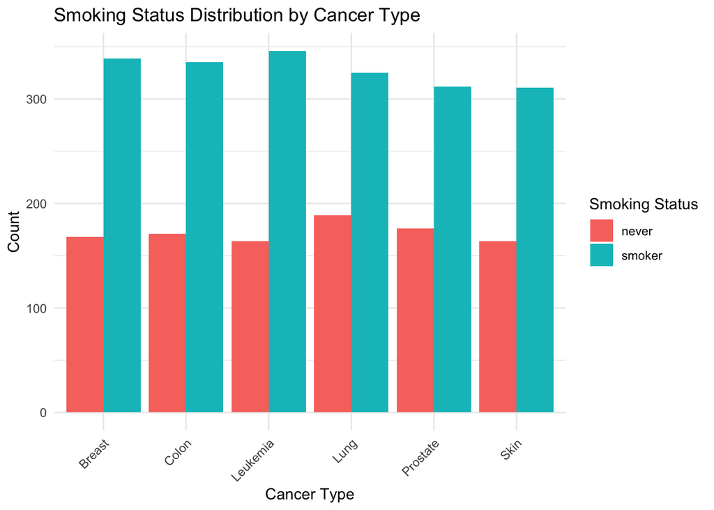

```r
smokers_simplified <- data %>% mutate(Smoking_Status = ifelse(Smoking_Status == "Never", "never", "smoker"))
plot_smoking_simplified <- ggplot(smokers_simplified, aes(x = Cancer_Type, fill = Smoking_Status)) +
  geom_bar(position = "dodge") +  # proportions within cancer type
  labs(title = "Smoking Status Distribution by Cancer Type",
       x = "Cancer Type",
       y = "Count",
       fill = "Smoking Status") +
  theme_minimal() +
  theme(axis.text.x = element_text(angle = 45, hjust = 1))

ggsave("plots/smoking_simplified.png", plot = plot_smoking_simplified, width = 8, height = 6, dpi = 300, bg = "white")

plot_smoking_simplified
```

As expected, smokers (former and current) make up a higher proportion of patients in each cancer type.

Before further analysis, I want to repeat these steps for alcohol consumption.

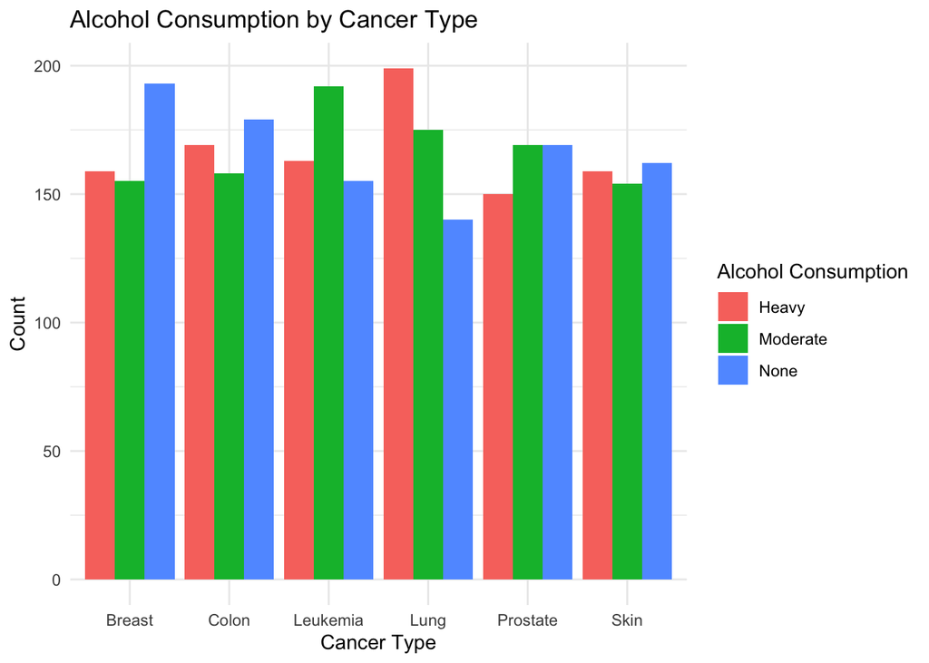

```r
plot_alcohol <- ggplot(data, aes(x = Cancer_Type, fill = Alcohol_Consumption)) +
  geom_bar(position = "dodge") +
  labs(title = "Alcohol Consumption by Cancer Type",
       x = "Cancer Type",
       y = "Count",
       fill = "Alcohol Consumption") +
  theme_minimal()

ggsave("plots/alcohol.png", plot = plot_alcohol, width = 8, height = 6, dpi = 300, bg = "white")

plot_alcohol
```

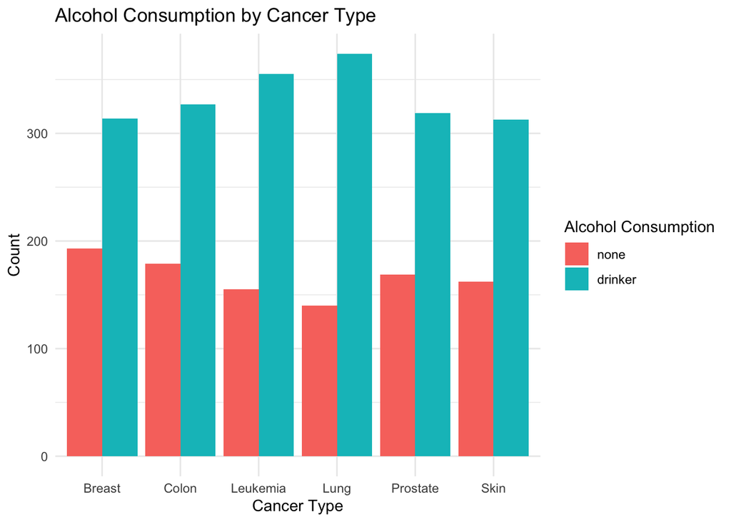

```r
alcohol_simplified <- data %>% mutate(Alcohol_Consumption = ifelse(Alcohol_Consumption == "None", "none", "drinker"), Alcohol_Consumption = factor(Alcohol_Consumption, levels = c("none", "drinker"))
  )
plot_alcohol_simplified <- alcohol_simplified %>% ggplot(aes(x = Cancer_Type, fill = Alcohol_Consumption)) +
  geom_bar(position = "dodge") +
  labs(title = "Alcohol Consumption by Cancer Type",
       x = "Cancer Type",
       y = "Count",
       fill = "Alcohol Consumption") +
  theme_minimal()

ggsave("plots/alcohol_simplified.png", plot = plot_alcohol_simplified, width = 8, height = 6, dpi = 300, bg = "white")

plot_alcohol_simplified
```

I was also interested in the family history of these patients. This is a good way to test the “genetic” component of cancer, though of course there are always many factors at play.

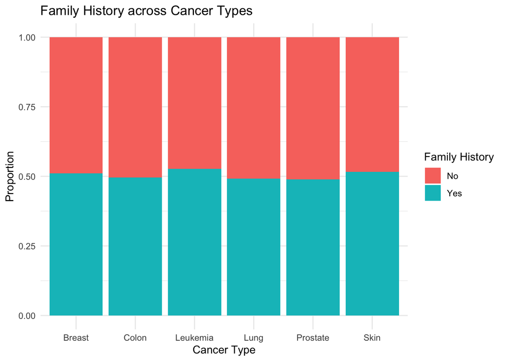

```r
plot_family_history <- ggplot(data, aes(x = Cancer_Type, fill = Family_History)) + geom_bar(position = "fill") + labs(title = "Family History across Cancer Types", x = "Cancer Type", y = "Proportion", fill = "Family History") + theme_minimal()

ggsave("plots/family_history.png", plot = plot_family_history, width = 8, height = 6, dpi = 300, bg = "white")

plot_family_history
```

Next, I wanted to see what kind of treatments these patients received, how common each treatment was, and whether one type of cancer got treated with a specific treatment more than others, etc. Below I explored the trends with different types of treatments included in the dataset.

```r
data %>% count(Treatment_Type)
```

```
## # A tibble: 5 × 2
##   Treatment_Type      n
##   <chr>           <int>
## 1 Chemotherapy      611
## 2 Hormone Therapy   586
## 3 Immunotherapy     612
## 4 Radiation         594
## 5 Surgery           597
```

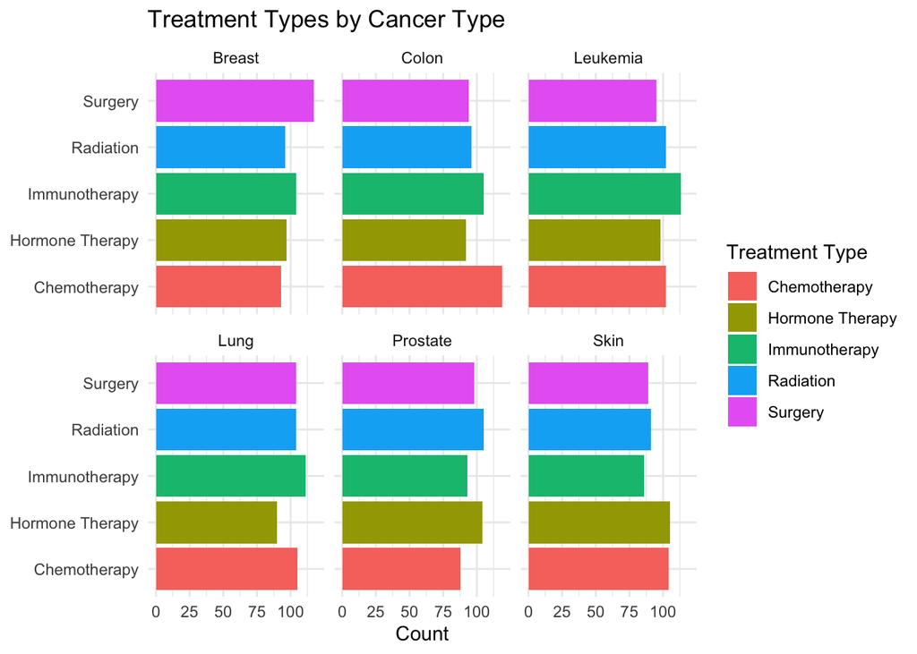

```r
plot_treatment_facet <- data %>%
  ggplot(aes(x = Treatment_Type, fill = Treatment_Type)) +
  geom_bar(position = "dodge") +
  facet_wrap(~ Cancer_Type) + #facet_wrap creates a subplot for each cancer type
  coord_flip() + #flipped coordinates bc labels are easier to read horizontally
  labs(
    title = "Treatment Types by Cancer Type",
    x = NULL,
    y = "Count",
    fill = "Treatment Type"
  ) +
  theme_minimal()

ggsave("plots/treatments.png", plot = plot_treatment_facet, width = 8, height = 6, dpi = 300, bg = "white")

plot_treatment_facet
```

I noticed that there is also a variable called “Stage,” which depicts which stage the cancer was diagnosed in. I wondered if there are any links between cancer progression and the type of treatment provided.

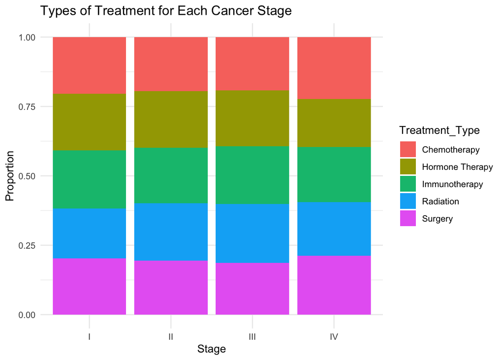

```r
plot_treatment_per_stage <- ggplot(data, aes(x = Stage, fill = Treatment_Type)) + geom_bar(position = "fill") + labs(title = "Types of Treatment for Each Cancer Stage", x = "Stage", y = "Proportion") + theme_minimal()

ggsave("plots/treatment_per_stage.png", plot = plot_treatment_per_stage, width = 8, height = 6, dpi = 300, bg = "white")

plot_treatment_per_stage
```

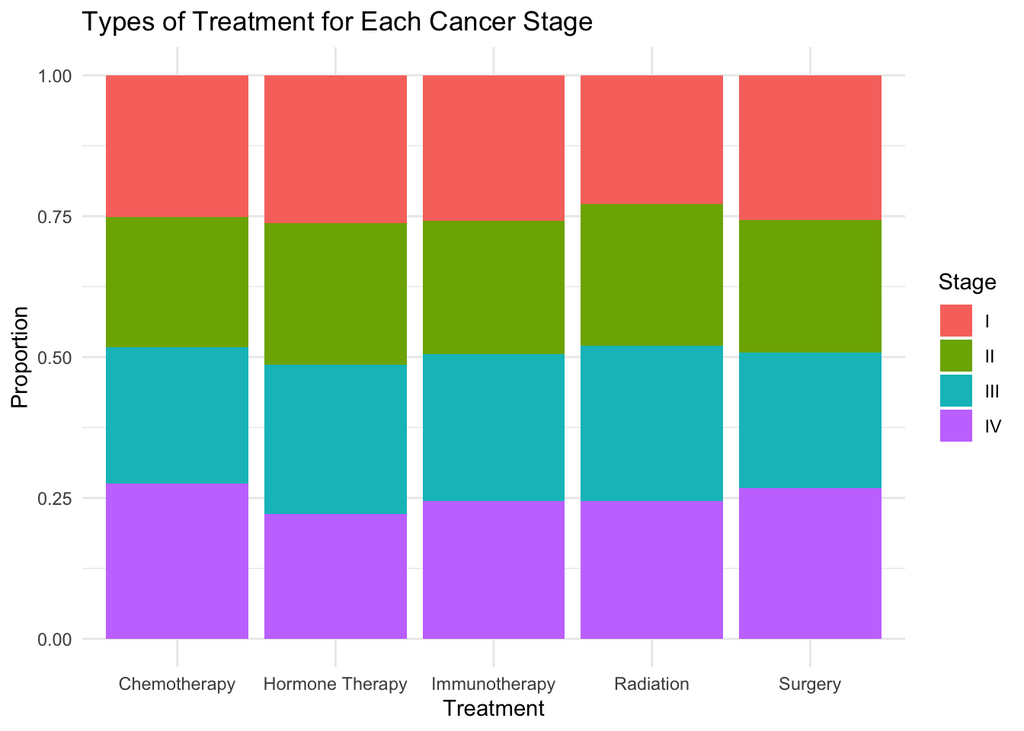

```r
plot_stage_per_treatment <- ggplot(data, aes(x = Treatment_Type, fill = Stage)) + geom_bar(position = "fill") + labs(title = "Types of Treatment for Each Cancer Stage", x = "Treatment", y = "Proportion") + theme_minimal()

ggsave("plots/stage_per_treatment.png", plot = plot_stage_per_treatment, width = 8, height = 6, dpi = 300, bg = "white")

plot_stage_per_treatment
```

It seems like every therapy has been used with cancers at every stage in this dataset. That is good to know; the dataset once again seems to be very balanced.

Finally, I wanted to take a look at the mutations variable of the dataset.

```r
count(data, Genetic_Mutation)
```

```
## # A tibble: 4 × 2
##   Genetic_Mutation     n
##   <chr>            <int>
## 1 BRCA1              714
## 2 BRCA2              754
## 3 None               789
## 4 TP53               743
```

Seems like there are only four observations for genetic mutation: BRCA1, BRCA2, TP53, and none.

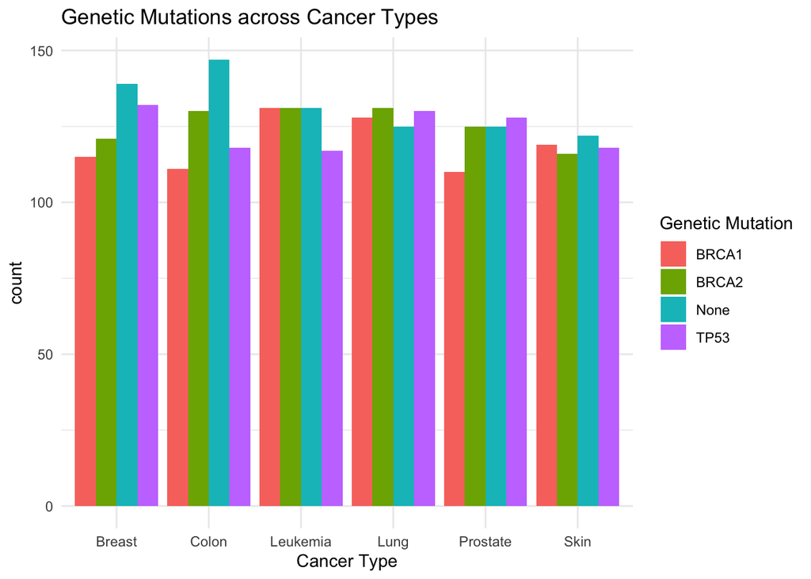

```r
plot_mutations <- ggplot(data, aes(x = Cancer_Type, fill = Genetic_Mutation)) + geom_bar(position = "dodge") + labs(title = "Genetic Mutations across Cancer Types", x = "Cancer Type", fill = "Genetic Mutation") + theme_minimal()

ggsave("plots/mutations.png", plot = plot_mutations, width = 8, height = 6, dpi = 300, bg = "white")

plot_mutations
```

```r
mutations <- data %>% filter(Genetic_Mutation %in% c("BRCA1", "BRCA2", "TP53"))
mutations
```

```
## # A tibble: 2,211 × 25
##    Patient_ID   Age Gender Region      Cancer_Type Stage Diagnosis_Date
##         <dbl> <dbl> <chr>  <chr>       <chr>       <chr> <date>
##  1          1    69 Male   Hovedstaden Leukemia    III   2015-06-26
##  2          3    47 Female Syddanmark  Prostate    II    2017-09-17
##  3          4    66 Male   Midtjylland Skin        I     2018-03-07
##  4          5    72 Male   Syddanmark  Breast      II    2019-11-09
##  5          6    35 Female Hovedstaden Skin        II    2018-09-29
##  6          7    70 Male   Syddanmark  Colon       III   2023-03-28
##  7         11    31 Male   Sjælland    Prostate    II    2021-01-14
##  8         12    57 Male   Nordjylland Breast      I     2018-09-19
##  9         13    70 Female Sjælland    Skin        II    2018-07-19
## 10         14    88 Female Hovedstaden Skin        II    2020-02-14
## # ℹ 2,201 more rows
## # ℹ 18 more variables: Treatment_Type <chr>, Treatment_Start_Date <date>,
## #   Treatment_End_Date <date>, Tumor_Size_cm <dbl>, Lymph_Nodes_Examined <dbl>,
## #   Lymph_Nodes_Positive <dbl>, Metastasis <chr>, Genetic_Mutation <chr>,
## #   Smoking_Status <chr>, Alcohol_Consumption <chr>, BMI <dbl>,
## #   Comorbidities <chr>, Family_History <chr>, Survival_Months <dbl>,
## #   Relapse <chr>, Occupation <chr>, Income_Level <chr>, Followup_Date <date>
```

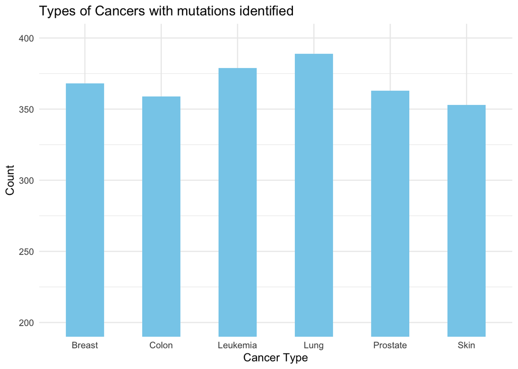

```r
plot_cancertype_with_mutation <- mutations %>% ggplot(aes(x = Cancer_Type)) + geom_bar(fill = "skyblue", width = 0.5) + coord_cartesian(ylim = c(200, 400)) + labs(title = "Types of Cancers with mutations identified", x = "Cancer Type", y = "Count") + theme_minimal()

ggsave("plots/cancertype_mutations.png", plot = plot_cancertype_with_mutation, width = 8, height = 6, dpi = 300, bg = "white")

plot_cancertype_with_mutation
```

Seems like lung cancer patients of this dataset have the most number of mutations identified. From one of the earlier plots we know that all three mutations “BRCA1”, “BRCA2” and “TP53” are observed at similar counts in this cancer type, so I didn’t plot that again separately. Instead, I decided to “zoom in” on this particular cancer type. To practice, I decided to try to build a predictive model of survival for lung cancer patients, using the data I have at hand.

## Building a predictive model of survival for lung cancer

First, I need to set the stage for what I want to do. Below, I documented some preliminary steps, some of which were completely new to me, so I tried to take good notes.

```r
#First, filter the data to get a data frame with only lung cancer cases
lung_data <- data %>%
  filter(Cancer_Type == "Lung") %>%
  drop_na(Survival_Months)

#Next, select the columns/variables you want to keep as "predictors" of survival
lung_model_data <- lung_data %>%
  select(Age, Gender, Cancer_Type, Stage, Smoking_Status, Alcohol_Consumption, BMI, Income_Level)
lung_model_data$Stage <- factor(lung_model_data$Stage, ordered = TRUE)

#training
set.seed(123) #makes sure random split is repeatable, otherwise i'd get a new split each time
train_indices <- sample(nrow(lung_model_data), 0.8 * nrow(lung_model_data)) #This gives me a random list of row numbers to be used for "training," all of which are saved in train_indices
#sample() randomly picks 80% of rows
#nrow() total number of rows in the dataset

train_data <- lung_model_data[train_indices, ]
test_data <- lung_model_data[-train_indices, ] #all the rows that are remaining (bc of the -)
```

In these steps I filtered and selected certain factors from my dataset in order to create the data frame I’ll be working with, which consists only of lung cancer patients and the “predictor” variables I decided to focus on. In the last section I included a “training/testing” step, where I “split” the data into two: one part (80%) used for training the model, the rest (20%) used to test the model.

I learned that if you use the exact same data to both “train” and “test” your model, even if it’s not working properly (i.e. if it is only memorizing things rather than actually “learning”) everything will seem to work perfectly. To make sure that this isn’t happening, I train and test the model with different parts of my data. Basically, I make sure that the model works even with new, previously unseen data.

Now, it’s time to build the model!